# Literate Programming

2025 DSS Bootcamp

Colin Rundel

# R, R Markdown, and Quarto

## What is markdown?

- Markdown is a lightweight markup language for creating HTML (and other formatted) documents.
- Markup languages are designed to produce documents from human readable text (and annotations).
- Some of you may be familiar with LaTeX. This is another (less human friendly) markup language for creating pdf documents.
- Why markdown is great:
  - Easy to learn and use.
  - Focus on **content**, rather than **coding** and debugging **errors**.
  - Once you have the basics down, you can get fancy via HTML, JavaScript, and CSS.
  - Used by R Markdown, Jupyter Notebooks, and Quarto

## R Markdown / Quarto - Input

R Markdown:

````markdown
---
title: "Untitled"
output: html_document
date: "2023-08-22"
---

```{r setup, include=FALSE}
knitr::opts_chunk$set(echo = TRUE)
```

## R Markdown

This is an R Markdown document. Markdown is a simple formatting syntax for authoring HTML, PDF, and MS Word documents. For more details on using R Markdown see <http://rmarkdown.rstudio.com>.

When you click the **Knit** button a document will be generated that includes both content as well as the output of any embedded R code chunks within the document. You can embed an R code chunk like this:

```{r cars}
summary(cars)
```

## Including Plots

You can also embed plots, for example:

```{r pressure, echo=FALSE}
plot(pressure)
```

Note that the `echo = FALSE` parameter was added to the code chunk to prevent printing of the R code that generated the plot.
````

Quarto:

````markdown
---
title: "Untitled"
format: html
---

## Quarto

Quarto enables you to weave together content and executable code into a finished document. To learn more about Quarto see <https://quarto.org>.

## Running Code

When you click the **Render** button a document will be generated that includes both content and the output of embedded code. You can embed code like this:

```{r}
1 + 1
```

You can add options to executable code like this

```{r}
#| echo: false
2 * 2
```

The `echo: false` option disables the printing of code (only output is displayed).
````

## R Markdown / Quarto - Output

**Something simple**

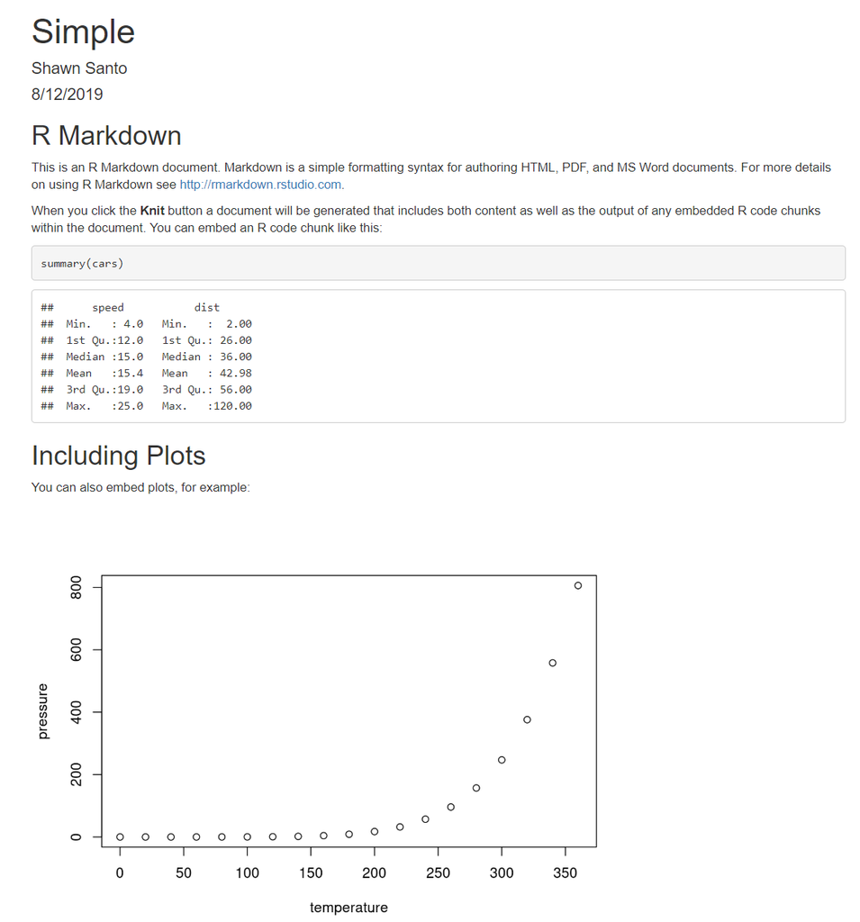

**Something fancy**

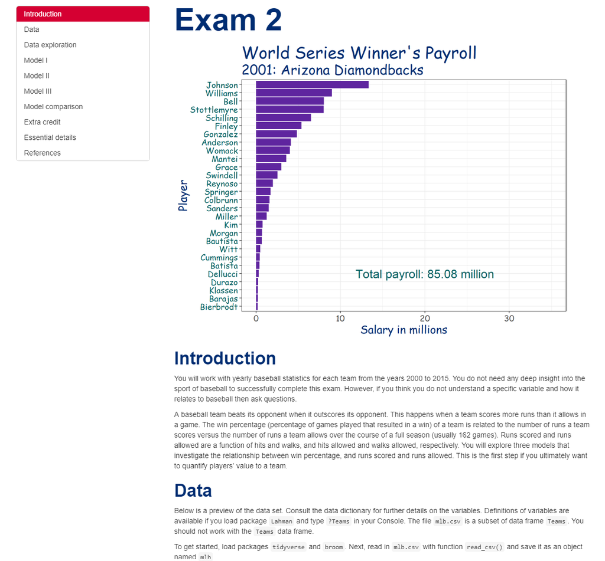

## R Markdown resources

- In RStudio, go to `Help > Cheatsheets` and select
  - R Markdown Cheat Sheet
  - R Markdown Reference Guide
- Check out the official R Markdown book: [R Markdown: The Definitive Guide](https://bookdown.org/yihui/rmarkdown/) by Yihui Xie, J. J. Allaire, and Garrett Grolemund
- Check out [bookdown: Authoring Books and Technical Documents with R Markdown](https://bookdown.org/yihui/bookdown/) by Yihui Xie.
- Take a look at [RPubs](http://rpubs.com/) web published R Markdown documents.

## Quarto resources

- Much of the syntax is shared with R Markdown - so previous resources are a good place to start
- [quarto.org](https://quarto.org/)
- Tom Mock’s [Intro to Quarto webinar](https://jthomasmock.github.io/quarto-2hr-webinar/)
- RStudioConf 2023 workshops
  - [Getting Started with Quarto](https://rstudio-conf-2023.github.io/get-started-quarto/)
  - [From R Markdown to Quarto](https://rstudio-conf-2023.github.io/rmd-to-quarto/)

# Quarto / RMarkdown demo

## R packages

- Packages are the fundamental units of reproducible R code. They include reusable R functions, the documentation that describes how to use them, and sample data.
- In the following exercises we’ll use the `tidyverse` package.
  - The tidyverse is an opinionated collection of R packages designed for data science. All packages share an underlying design philosophy, grammar, and data structures.
  - The core tidyverse packages consists of `ggplot2`, `tibble`, `tidyr`, `readr`, `purrr`, `dplyr`, `stringr`, and `forcats` packages.
- This package is already installed for you on the DSS servers. If needed, you can install it by running the following in the `Console`:

  ```r
  install.packages("tidyverse")
  ```

## A note on environments

- Your R Markdown / Quarto document and your Console do not share their global environments.
  - This is different than the computational model of Jupyter Notebooks!
- This is good for reproducibility, but can sometimes result in frustrating errors.
- This also means any packages or data needed for your analysis need to be loaded in your R Markdown document as well.

## Unvotes data analysis

To get started,

- open `examples/unvotes.qmd`,
- try Rendering the entire document and examine the results.
- try changing one or more of the selected countries, re-render the document and observe any changes.
- commit and push your changes to GitHub

## R Markdown / quarto suggestions

- Remember to name your code chunks
- Familiarize yourself with chunk options (https://yihui.org/knitr/options/)
  - Use global chunk options to reduce duplication
  - Using `#|` syntax enables tab completion for chunk options
- Load packages at the start of a document, generally the chunk after your setup chunk
- Familiarize yourself with various output formats: Make slides with `revealjs`, pdfs, books, etc.

These slides were made with quarto and `revealjs`.

## R programming resources

- Style
  - [Tidyverse style guide](http://style.tidyverse.org/)
  - [Google’s R style guide](https://google.github.io/styleguide/Rguide.html)
- Beginner
  - [swirl](https://swirlstats.com/): swirl teaches you R programming and data science interactively, at your own pace, and right in the R console
  - [R manuals](https://cran.r-project.org/manuals.html)
  - [R for Data Science](https://r4ds.had.co.nz) by Hadley Wickham and Garrett Grolemund
  - [R Cookbook](https://www.amazon.com/gp/product/0596809158/ref=as_li_tf_tl?ie=UTF8&camp=1789&creative=9325&creativeASIN=0596809158&linkCode=as2&tag=cooforr09-20) by Paul Teetor
- Next steps
  - [Advanced R](https://adv-r.hadley.nz/) by Hadley Wickham
  - [R Packages](http://r-pkgs.had.co.nz/) by Hadley Wickham